# Citation Diversity Tracking: Further analysis (Median split by Publication Year, Analyses by Journal Impact Factor)

- authored by: **[Lioba Enk](https://www.cbs.mpg.de/person/enk/1770355), Spokesperson for the Diversity and Inclusion Committee (MPI CBS, Leipzig, Germany)[^1]**
- last updated: **28 Jan 2026**

#### Reference

Steinfath, P. *, Azanova, M. *, Kapralov, N. *, Loesche, T., Enk, L., Nikulin, V. ° & Villringer, A. °. *Heartbeat-evoked responses in M/EEG: A systematic review of methods with suggestions for analysis and reporting*. Manuscript submitted for publication (2025-08).

**Code sections (A) + (B)** reported in :  
Main text under ‘*Statement on gender composition within HER research and citation diversity*’  
(Steinfath, Azanova, Kapralov et al., 2025)

**Code sections (C)** reported in :  
Section E (Steinfath, Azanova, Kapralov et al., 2025)

#### Description

This script processes output from **[`citation-diversity-tracking (v2.0)`](https://github.com/liobaenk/citation-diversity-tracking)**, specifically for Steinfath, Azanova, Kapralov et al. (2025). The output can be found at [/manuscript-results/2025_steinfath-et-al_hep-review](https://github.com/liobaenk/citation-diversity-tracking/manuscript-results/2025_steinfath-et-al_hep-review/output/).

Further analyses were conducted on the corpus of literature included to this systematic review. This was a new opportunity, to further describe development across the reviewed Heart-beat evoked reponses (HER) studies published over time. In the soon future, I hope to integrate these analyses into the main `citation-diversity-tracking` tool.

The input file for this code is an adapted `citation-diversity-tracking` output file, and can be found at manuscript-results/2025_steinfath-et-al_hep-review/ReviewLit:

- ‘20250619_hep_review_trackcitingbehav_predictions_checked_FALAclustering_MedianSplitYear_EigenfactorGrouping.csv’

Note, some information was added **manually** to the input file (column labels):

- PublicationMonth: Publication months across the references publsihed at median(PublicationYear), here 2020.
- Eigenfactor_JCR_2024: extracted from the Web of Science’s Journal Citation Report data on 23 June 2025, if available.
- Eigenfactor_JCR_PublicationYear: extracted from the Web of Science’s Journal Citation Report data on 23 June 2025, if available.
- Dworkin_5_member: Top 5 Neuroscience Journals (across 1995-2018), that is Neuron, Nat Neurosci, J Neurosci, NeuroImage, Brain, extracted from [Dworkin et al. (Nat Neurosci 2020)](https://doi.org/10.1038/s41593-020-0658-y).  
  –> /data/configs/eigenfactor_dworkin_hefter_grouping.csv.
- Hefter_50_member: Top 50 Neuroscience Journals (as of Sept 2023), extracted from *‘Supplementary Information for “Gender imbalance in citations most pronounced in high-impact neuroscience journals”’ (p. 15)* of [Hefter et al. (bioRxiv 2025)](https://doi.org/10.1101/2025.02.19.638905).  
  –> /data/configs/eigenfactor_dworkin_hefter_grouping.csv

This script computes (**A**) a median split by publication year to assess changes in approximated gender ratios (FF / MF / FM / MM) of authors, (**B**) clustering of author names in first and last authoring position, and (**C**) changes in those approximated gender proportions by Eigenfactor score ([Bergstrom et al., 2008](https://doi.org/10.1523/JNEUROSCI.0003-08.2008)).

#### (_) Package dependencies

```r
library(rmarkdown)
library(insight)
library(svDialogs)
library(dplyr)
library(tidyr)
library(ggplot2)
library(ggpubr)
library(svglite)
```

#### (_) Paths and read Input

```r
inpath = "ReviewLit/"
outpath = "output/ReviewLit"

data = read.csv(
  paste(inpath,
        "20250619_hep_review_trackcitingbehav_predictions_checked_FALAclustering_MedianSplitYear_EigenfactorGrouping.csv",sep=""))

data_all = read.csv(
  "output/ReviewLit/20250810_hep-review_citationdiversitytracking_predictions_checked.csv")
```

**Note**: We run the analyses only on references with assigned gender.

```r
n_excluded = nrow(data[(data$Dworkin_5_member == "excluded"),])
data = data[!(data$Dworkin_5_member == "excluded"),]
```

#### (**A**) Median Split by Publication Year

```r
med = median(data$PublicationYear)
data$PublicationYear_mediansplit = ifelse(data$PublicationYear < med,
                                          "below_median", "above_median")

table(data$PublicationYear_mediansplit)
```

```
##
## above_median below_median
##           73           57
```

```r
cat(paste("References with PublicationYear equal to the median = ",as.character(med),sep=""))
```

```
## References with PublicationYear equal to the median = 2020
```

|  | CitationKey | DOI | PublicationYear | PublicationMonth | PublicationYear_mediansplit |
| --- | --- | --- | --- | --- | --- |
| 5 | schulz_distinctive_2020 | 10.1016/j.jpsychores.2020.110223 | 2020 | 8 | above_median |
| 44 | flasbeck_altered_2020 | 10.1186/s40479-020-00139-1 | 2020 | 10 | above_median |
| 52 | marshall_interoceptive_2020 | 10.1037/emo0000631 | 2020 | 10 | above_median |
| 61 | salamone_dynamic_2020 | 10.1093/braincomms/fcaa095 | 2020 | 7 | above_median |
| 62 | al_heartbrain_2020 | 10.1073/pnas.1915629117 | 2020 | 5 | above_median |
| 66 | banellis_skipping_2020 | 10.1093/texcom/tgaa060 | 2020 | 9 | above_median |
| 72 | schmitz_heart_2020 | 10.1016/j.jad.2019.11.139 | 2020 | 3 | above_median |
| 75 | kato_alterations_2020 | 10.3389/fpsyt.2020.00683 | 2020 | 7 | above_median |
| 114 | fittipaldi_multidimensional_2020 | 10.1016/j.neuroimage.2020.116677 | 2020 | 5 | above_median |
| 120 | solca_behavioral_2020 | 10.1016/j.neuroimage.2020.116902 | 2020 | 8 | above_median |

```r
value = (table(data$PublicationYear_mediansplit)[1] -
           table(data$PublicationYear_mediansplit)[2]) / 2
```

```
## The *8* references from 2020 published earliest, need to be 'below_median'.
```

```r
data[data$PublicationYear == med &
       data$PublicationMonth <= 9,"PublicationYear_mediansplit"] = "below_median"
```

|  | CitationKey | DOI | PublicationYear | PublicationMonth | PublicationYear_mediansplit |
| --- | --- | --- | --- | --- | --- |
| 5 | schulz_distinctive_2020 | 10.1016/j.jpsychores.2020.110223 | 2020 | 8 | below_median |
| 44 | flasbeck_altered_2020 | 10.1186/s40479-020-00139-1 | 2020 | 10 | above_median |
| 52 | marshall_interoceptive_2020 | 10.1037/emo0000631 | 2020 | 10 | above_median |
| 61 | salamone_dynamic_2020 | 10.1093/braincomms/fcaa095 | 2020 | 7 | below_median |
| 62 | al_heartbrain_2020 | 10.1073/pnas.1915629117 | 2020 | 5 | below_median |
| 66 | banellis_skipping_2020 | 10.1093/texcom/tgaa060 | 2020 | 9 | below_median |
| 72 | schmitz_heart_2020 | 10.1016/j.jad.2019.11.139 | 2020 | 3 | below_median |
| 75 | kato_alterations_2020 | 10.3389/fpsyt.2020.00683 | 2020 | 7 | below_median |
| 114 | fittipaldi_multidimensional_2020 | 10.1016/j.neuroimage.2020.116677 | 2020 | 5 | below_median |
| 120 | solca_behavioral_2020 | 10.1016/j.neuroimage.2020.116902 | 2020 | 8 | below_median |

```
## Resulting in...
```

```
##
## above_median below_median
##           65           65
```

Summarise…

| PublicationYear_mediansplit | GendCat_posthoc | your_count | your_percent |
| --- | --- | --- | --- |
| above_median | mm | 23 | 35.384615 |
| above_median | fm | 18 | 27.692308 |
| above_median | mf | 9 | 13.846154 |
| above_median | ff | 15 | 23.076923 |
| below_median | mm | 30 | 46.153846 |
| below_median | fm | 22 | 33.846154 |
| below_median | mf | 4 | 6.153846 |
| below_median | ff | 9 | 13.846154 |

Difference between above median (from 10/2020) and below median (before 10/2020).

| GendCat | Delta_AboveMed_BelowMed |
| --- | --- |
| mm | -10.769231 |
| fm | -6.153846 |
| mf | 7.692308 |
| ff | 9.230769 |

#### (**B**) Clustering of author names in first and last authoring position

Add First Author information…

```r
data = cbind( data[1:3], FirstAuthor = NA, data[4:ncol(data)] )
for (i in 1:nrow(data)) {
  data$FirstAuthor[i] = data_all[data_all$CitationKey == data$CitationKey[i] &
                                   data_all$GendCat == "","Author"]
}
```

**Cutoff value for clustering ≥ 5 references by the same name**

**Last Author Clustering**

```r
table(data$LastAuthor)
```

```
##
##             Achim,Mller           Agustin,Ibaez          Agustin,Ibanez
##                       1                       3                       3
##            Agustin,Ibez             Agustn,Ibez           Alejandra,Sel
##                       5                       1                       1
##            Andre,Schulz          Andrea,Mannini         Antonio,Pereira
##                       1                       1                       1
##         Arno,Villringer      Bigna,Lenggenhager           Bumseok,Jeong
##                       3                       2                       1
##         Calixto,Machado Catherine,Tallon-Baudry               Chunbo,Li
##                       2                       8                       1
##             Claus,Vgele        Cristina,Berchio            Damian,Cruse
##                       2                       1                       1
##            DeMond,Grant          Diego,Cosmelli    Enrica,Santarcangelo
##                       1                       1                       2
##                 Eus,Van         Francesca,Ferri       Francois,Vialatte
##                       1                       2                       1
##        Friedrich,Strian         Gaetano,Valenza            Gregor,Domes
##                       2                       1                       1
##      Hartmut,Schchinger                 Hin,Sik          Hugo,Critchley
##                       2                       1                       1
##   Inga,Grikova-Bulanova             Jacobo,Sitt             Jane,Aspell
##                       1                       2                       1
##    Joydeep,Bhattacharya             Juan,Barcia           Katja,Bertsch
##                       1                       1                       3
##           Klaas,Stephan            Kristl,Vonck        Laura,Sebastiani
##                       1                       1                       1
##             Lucas,Sedeo       Mahinda,Yogarajah          Manos,Tsakiris
##                       4                       1                       3
##           Marc,Wittmann            Martijn,Arns             Martin,Brne
##                       2                       1                       2
##               Marzia,De           Masato,Fukuda         Mathias,Baumert
##                       1                       1                       1
##          Mathias,Weymar         Matthias,Michal            Milton,Brown
##                       1                       1                       1
##        Muhammad,Qureshi       Nava,Levit-Binnun             Olaf,Blanke
##                       1                       1                       2
##           Olga,Pollatos      Pandelis,Perakakis           Pedro,Montoya
##                       2                       2                       1
##             Pengmin,Qin              Pter,Simor         Rainer,Schandry
##                       1                       1                       3
##         Raymond,Bradley          Rolf,Weitkunat            Sahib,Khalsa
##                       1                       3                       1
##         Sarah,Benghanem           Satoshi,Umeda         Shigeto,Ymawaki
##                       1                       3                       1
##              Shuxia,Yao    Simone,Schtz-Bosbach     Simone,SchtzBosbach
##                       1                       6                       1
##         Sophie,Schwartz          Stefan,Debener         Stoyan,Popkirov
##                       1                       1                       1
##           Thomas,Kammer    Tristan,Bekinschtein           Vadim,Nikulin
##                       1                       1                       1
##           Vladimir,Lpez            Weidong,Wang       Wolfgang,Klimesch
##                       1                       2                       1
##             Xiaoping,Li          Yoshihiro,Noda             Yvan,Devaux
##                       1                       1                       1
```

Manual Correct…

```r
data[data$LastAuthor == "Agustin,Ibaez" |
       data$LastAuthor == "Agustin,Ibez" |
       data$LastAuthor == "Agustn,Ibez" ,"LastAuthor"] = "Agustin,Ibanez"

data[data$LastAuthor == "Simone,SchtzBosbach","LastAuthor"] = "Simone,Schtz-Bosbach"
```

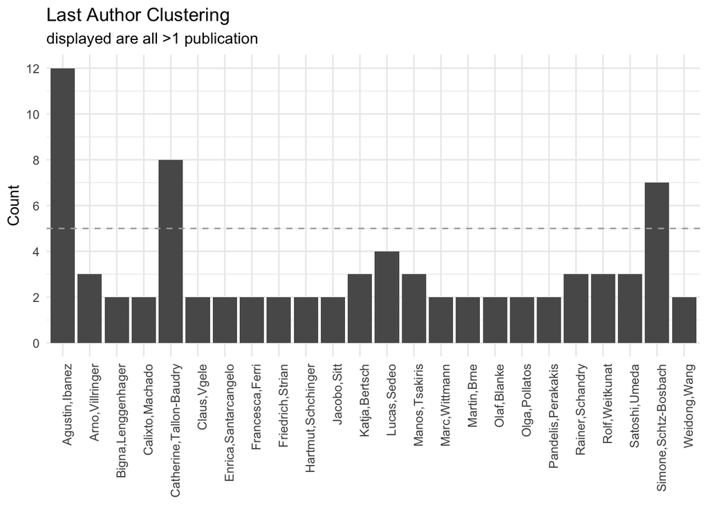

```r
data_LA_above1 = data %>%
  group_by(LastAuthor) %>%
  filter(n() > 1) %>%
  ungroup()

data_LA_above1 %>%
  count(LastAuthor) %>%
  ggplot(aes(x = LastAuthor, y = n)) +
  geom_bar(stat = "identity") +
  geom_hline(yintercept = 5, linetype = "dashed", color = "darkgrey") +
  scale_y_continuous(breaks = c(0,2,4,6,8,10,12,14)) +
  labs(x = "Value", y = "Count",
       title = "Last Author Clustering",
       subtitle = "displayed are all >1 publication") +
  theme_minimal() +
  theme(axis.text.x = element_text(angle = 90, hjust = 1),
        axis.title.x = element_blank())
```

```r
percentage_LA_5clustered = round(
  nrow(data[(data$LastAuthor == "Agustin,Ibanez" |
               data$LastAuthor == "Simone,Schtz-Bosbach" |
               data$LastAuthor == "Catherine,Tallon-Baudry"),])
  / (nrow(data) + n_excluded) * 100,3)

# percentage_LA_5clustered = round(
#   nrow(data[(data$LastAuthor == "Agustin,Ibanez" |
#                data$LastAuthor == "Simone,Schtz-Bosbach" |
#                data$LastAuthor == "Catherine,Tallon-Baudry"),])
#   / nrow(data) * 100,3)
```

```
## **20.455%** of 132 included studies were last authored by a set of three names.
```

**First Author Clustering**

```r
table(data$FirstAuthor)
```

```
##
##           Adrian,Yoris         Agustina,Birba         Agustina,Legaz
##                      3                      1                      1
##         Akihiro,Koreki          Alejandra,Sel      Alejandro,Callara
##                      1                      1                      1
##             Alethia,De        Amanda,Marshall           Andre,Schulz
##                      1                      5                      5
##         Andrea,Zaccaro Andres,Canales-Johnson     Andria,Pelentritou
##                      2                      1                      1
##              Anne,Buot            Annika,Lutz          Antje,Gentsch
##                      1                      1                      1
##      Ayham,Alkhachroum       Bertrand,Hermann             Blas,Couto
##                      1                      1                      2
##     Carlos,VenturaBort            Caroline,Di        Charles,Verdonk
##                      1                      1                      2
##      Christian,Leopold       Damiano,Azzalini           Deniz,Kumral
##                      1                      1                      1
##    Diego,Candia-Rivera     Diego,CandiaRivera          Edward,Katkin
##                      4                      1                      1
##             Eline,Melo         Elsa,Fouragnan                Esra,Al
##                      1                      1                      3
##         Fabian,Richter   Frederike,Petzschner        Gerhard,Dirlich
##                      2                      1                      2
##           Gioia,Giusti     Hirokata,Fukushima            Hongyun,Liu
##                      1                      1                      2
##       Hyeong-Dong,Park   Indira,Garca-Cordero           Jaejoong,Kim
##                      2                      2                      1
##        Janneke,Terhaar          Jennifer,Todd           Jiaoyan,Pang
##                      1                      1                      1
##         Joaquin,Migeot              Juan,Prez        Julia,Lechinger
##                      1                      1                      1
##            Junling,Gao            Kentaro,Ono    Lampros,Perogamvros
##                      1                      1                      1
##           Lara,Maister            Laura,Mller     Lauren,Zwienenberg
##                      1                      1                      1
##          Leah,Banellis          Lilla,Hodossy          Lior,Kritzman
##                      1                      1                      1
##            Lorenz,Rapp          Lucia,Billeci             Marco,Solc
##                      1                      1                      1
##            Marcus,Gray    Mariana,Babo-Rebelo          Marieke,Weijs
```

[output cut: 10 more lines]

```
##                      1                      3                      1
##         Samia,Elkommos             Sandra,Mai         Sarah,Immanuel
##                      1                      1                      1
##        Shiva,Khoshnoud            Shiyun,Shao        Siri-Maria,Kamp
##                      2                      1                      2
##         Sol,Fittipaldi        Starr,MacKinnon          Susanne,Cambi
##                      1                      1                      1
##         Tahnee,Engelen           Tamas,Bogdny            Tasha,Poppa
##                      1                      1                      1
##           Umair,Majeed          Vera,Flasbeck            Yihui,Zhang
##                      1                      3                      1
##             Yishul,Wei             Yuichi,Ito            Yutaka,Kato
##                      1                      1                      1
##            Yuto,Tanaka
##                      1
```

Manual Correct…

```r
data[data$FirstAuthor == "Diego,CandiaRivera","FirstAuthor"] = "Diego,Candia-Rivera"
```

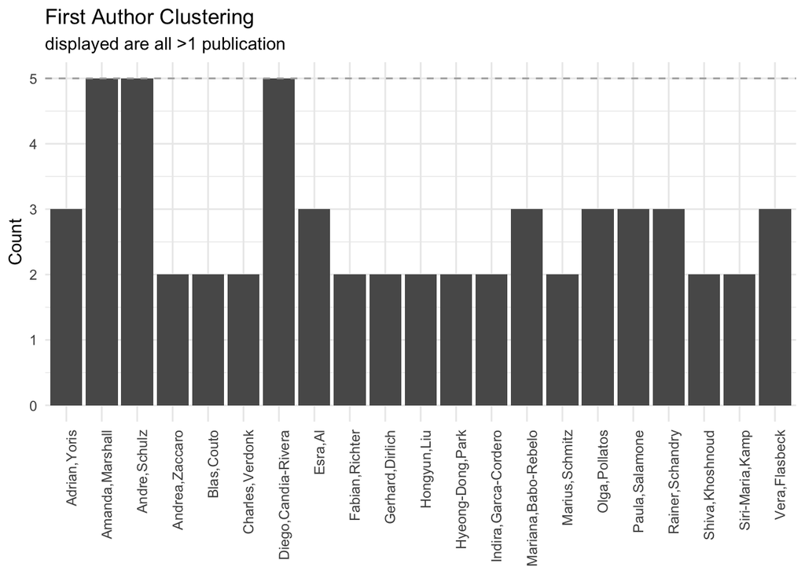

```r
data_FA_above1 = data %>%
  group_by(FirstAuthor) %>%
  filter(n() > 1) %>%
  ungroup()

data_FA_above1 %>%
  count(FirstAuthor) %>%
  ggplot(aes(x = FirstAuthor, y = n)) +
  geom_bar(stat = "identity") +
  geom_hline(yintercept = 5, linetype = "dashed", color = "darkgrey") +
  scale_y_continuous(breaks = c(0,1,2,3,4,5)) +
  labs(x = "Value", y = "Count",
       title = "First Author Clustering",
       subtitle = "displayed are all >1 publication") +
  theme_minimal() +
  theme(axis.text.x = element_text(angle = 90, hjust = 1),
        axis.title.x = element_blank())
```

```r
percentage_FA_5clustered = round(
  nrow(data[(data$FirstAuthor == "Amanda,Marshall" |
               data$FirstAuthor == "Andre,Schulz" |
               data$FirstAuthor == "Diego,Candia-Rivera"),])
  / (nrow(data) + n_excluded) * 100,3)

# percentage_FA_5clustered = round(
#   nrow(data[(data$FirstAuthor == "Amanda,Marshall" |
#                data$FirstAuthor == "Andre,Schulz" |
#                data$FirstAuthor == "Diego,Candia-Rivera"),])
#   / nrow(data) * 100,3)
```

```
## **11.364%** of 132 included studies were first authored by a set of three names.
```

#### (**C**) Overview : Top 50 Neuroscience Journals in Hefter et al. (2025)

| Journal | Eigenfactor_JCR_2023_09_Hefter | X2023_Hefter_Group | X1995_to_2018_Dworkin |
| --- | --- | --- | --- |
| Neuron | 0.1293 | 1 | 1 |
| Nature Neuroscience | 0.1044 | 1 | 1 |
| NeuroImage | 0.0988 | 1 | 1 |
| Journal of Neuroscience | 0.0793 | 1 | 1 |
| Nature Human Behaviour | 0.0528 | 1 | 0 |
| Journal of Physiology-London | 0.0251 | 1 | 0 |
| Neural Networks | 0.0239 | 1 | 0 |
| Current Opinion in Neurobiology | 0.0201 | 1 | 0 |
| eNeuro | 0.0179 | 1 | 0 |
| Journal of Cerebral Blood Flow and Metabolism | 0.0177 | 1 | 0 |

[output cut: 40 more lines]

We analysed approximated gender compositions across three Eigenfactor Score groupings.

- **Procedure 1**: HER references published in ‘Dworkin-Top5’
- **Procedure 2**: HER references published in ‘Hefter-Top50’
- **Procedure 3**: HER references published in ‘Hefter-Top50’ & adding all HER references published in journals that had an Eigenfactor score (from the JCR 2024) higher than the lowest one included in Hefter et al., that is an *Eigenfactor score of 0.016*.
- Remaining HER references

Importantly, we made two further decisions: (1) Three journals included in Hefter et al. (2025) were now below Hefter et al.’s lowest score[^2] - *we decided to yet include them to Procedure 2*; (2) Four journals in which HER research was published did not have Eigenfactor scores when we checked (JCR 2024) - *we decided to include them to Procedure 3*.

**Decision (1)**

|  | CitationKey | Citation | Eigenfactor_JCR_2024 | Hefter_50_member |
| --- | --- | --- | --- | --- |
| 56 | schulz_cortisol_2013 | Psychoneuroendocrinology. 2013 Nov;38(11):2686-93. doi: 10.1016/j.psyneuen.2013.06.027. Epub 2013 Jul 11. | 0.01330 | Y |
| 57 | kamp_reduced_2023 | Neurosci Lett. 2023 Sep 25;814:137466. doi: 10.1016/j.neulet.2023.137466. Epub 2023 Aug 29. | 0.01517 | Y |
| 58 | todd_weaker_2021 | Cortex. 2021 Oct;143:254-266. doi: 10.1016/j.cortex.2021.07.006. Epub 2021 Sep 2. | 0.01341 | Y |

**Decision (2)**

|  | CitationKey | Citation | Eigenfactor_JCR_2024 |
| --- | --- | --- | --- |
| 59 | montoya_heartbeat_1993 | Electroencephalogr Clin Neurophysiol. 1993 May-Jun;88(3):163-72. doi: 10.1016/0168-5597(93)90001-6. | NA |
| 66 | banellis_skipping_2020 | Cereb Cortex Commun. 2020 Sep 1;1(1):tgaa060. doi: 10.1093/texcom/tgaa060. eCollection 2020. | NA |
| 67 | dirlich_cardiac_1997 | Electroencephalogr Clin Neurophysiol. 1997 Apr;102(4):307-15. doi: 10.1016/s0013-4694(96)96506-2. | NA |
| 68 | dirlich_topography_1998 | Electroencephalography and Clinical Neurophysiology | NA |
| 74 | maister_neurobehavioral_2017 | Elife. 2017 Aug 8;6:e25318. doi: 10.7554/eLife.25318. | NA |
| 77 | mccraty_electrophysiological_2004 | J Altern Complement Med. 2004 Apr;10(2):325-36. doi: 10.1089/107555304323062310. | NA |
| 85 | candia-rivera_conscious_2023 | Elife. 2023 Oct 27;12:e75352. doi: 10.7554/eLife.75352. | NA |

Create grouping variable…

```r
data = data %>%
  mutate(
    eigenfactor_grouping = case_when(Dworkin_5_member == "Y" ~ "Procedure1",
                                     Hefter_50_member == "Y" ~ "Procedure2",
                                     (Eigenfactor_JCR2024_above_lowest_Hefter_Cutoff_0.016 == "Y" |
                                        taken_as_above2024cutoff_because_HefterMember == "Y" |
                                        taken_as_above2024cutoff_because_NA == "Y") ~ "Procedure3",
                                     (Eigenfactor_JCR2024_above_lowest_Hefter_Cutoff_0.016 == "N" &
                                       Hefter_50_member != "Y") ~ "Remaining"))
```

**Procedure 1**

```r
procedure1_count = nrow(data[data$eigenfactor_grouping == "Procedure1",])
data[data$eigenfactor_grouping == "Procedure1",] %>%
  group_by(GendCat_posthoc) %>%
  summarise(count = n(),
            total_count = procedure1_count,
            your_percent = n() / procedure1_count * 100)
```

```
## # A tibble: 4 × 4
##   GendCat_posthoc count total_count your_percent
##   <fct>           <int>       <int>        <dbl>
## 1 mm                  3          19         15.8
## 2 fm                  6          19         31.6
## 3 mf                  5          19         26.3
## 4 ff                  5          19         26.3
```

**Procedure 1 & Procedure 2**

```r
procedure12_count = nrow(data[data$eigenfactor_grouping == "Procedure1" |
                                data$eigenfactor_grouping == "Procedure2",])
data[data$eigenfactor_grouping == "Procedure1" |
       data$eigenfactor_grouping == "Procedure2",] %>%
  group_by(GendCat_posthoc) %>%
  summarise(count = n(),
            total_count = procedure12_count,
            your_percent = n() / procedure12_count * 100)
```

```
## # A tibble: 4 × 4
##   GendCat_posthoc count total_count your_percent
##   <fct>           <int>       <int>        <dbl>
## 1 mm                 13          43         30.2
## 2 fm                 16          43         37.2
## 3 mf                  5          43         11.6
## 4 ff                  9          43         20.9
```

**Procedure 1 & Procedure 2 & Procedure 3**

```r
procedure123_count = nrow(data[data$eigenfactor_grouping == "Procedure1" |
                                 data$eigenfactor_grouping == "Procedure2" |
                                 data$eigenfactor_grouping == "Procedure3",])
data[data$eigenfactor_grouping == "Procedure1" |
       data$eigenfactor_grouping == "Procedure2" |
       data$eigenfactor_grouping == "Procedure3",] %>%
  group_by(GendCat_posthoc) %>%
  summarise(count = n(),
            total_count = procedure123_count,
            your_percent = n() / procedure123_count * 100)
```

```
## # A tibble: 4 × 4
##   GendCat_posthoc count total_count your_percent
##   <fct>           <int>       <int>        <dbl>
## 1 mm                 26          77         33.8
## 2 fm                 28          77         36.4
## 3 mf                  8          77         10.4
## 4 ff                 15          77         19.5
```

**Remaining**

```r
remaining_count = nrow(data[data$eigenfactor_grouping == "Remaining",])
data[data$eigenfactor_grouping == "Remaining",] %>%
  group_by(GendCat_posthoc) %>%
  summarise(count = n(),
            total_count = remaining_count,
            your_percent = n() / remaining_count * 100)
```

```
## # A tibble: 4 × 4
##   GendCat_posthoc count total_count your_percent
##   <fct>           <int>       <int>        <dbl>
## 1 mm                 27          53        50.9
## 2 fm                 12          53        22.6
## 3 mf                  5          53         9.43
## 4 ff                  9          53        17.0
```

**DONE!** 🦋